# Project: DETECTING THE REASONS OF CANCELING RESERVATIONS IN HOTELS

- Introduction
- Data Wrangling
- Methodology
- Conclusions

## Introduction

This project aims to find the factors of cancelling hotel reservation based on collected data.

```python
# imports
import numpy as np, pandas as pd, matplotlib.pyplot as plt
```

### The Dataset

The dataset used for this project is downloaded from kaggle website. it contains a variety of hotel reservations on formation collect it based on some potential factors.

This data set contains booking information for a city hotel and a resort hotel, and includes information such as when the booking was made, length of stay, the number of adults, children, and/or babies, and the number of available parking spaces, among other things.All personally identifying information has been removed from the data.

```python
# Importing the dataset
df = pd.read_csv('dataset.csv')
df.head()
```

|  | hotel | is_canceled | lead_time | arrival_date_year | arrival_date_month | arrival_date_week_number | arrival_date_day_of_month | stays_in_weekend_nights | stays_in_week_nights | adults | ... | deposit_type | agent | company | days_in_waiting_list | customer_type | adr | required_car_parking_spaces | total_of_special_requests | reservation_status | reservation_status_date |
| --- | --- | --- | --- | --- | --- | --- | --- | --- | --- | --- | --- | --- | --- | --- | --- | --- | --- | --- | --- | --- | --- |
| 0 | Resort Hotel | 0 | 342 | 2015 | July | 27 | 1 | 0 | 0 | 2 | ... | No Deposit | NaN | NaN | 0 | Transient | 0.0 | 0 | 0 | Check-Out | 2015-07-01 |
| 1 | Resort Hotel | 0 | 737 | 2015 | July | 27 | 1 | 0 | 0 | 2 | ... | No Deposit | NaN | NaN | 0 | Transient | 0.0 | 0 | 0 | Check-Out | 2015-07-01 |
| 2 | Resort Hotel | 0 | 7 | 2015 | July | 27 | 1 | 0 | 1 | 1 | ... | No Deposit | NaN | NaN | 0 | Transient | 75.0 | 0 | 0 | Check-Out | 2015-07-02 |
| 3 | Resort Hotel | 0 | 13 | 2015 | July | 27 | 1 | 0 | 1 | 1 | ... | No Deposit | 304.0 | NaN | 0 | Transient | 75.0 | 0 | 0 | Check-Out | 2015-07-02 |
| 4 | Resort Hotel | 0 | 14 | 2015 | July | 27 | 1 | 0 | 2 | 2 | ... | No Deposit | 240.0 | NaN | 0 | Transient | 98.0 | 0 | 1 | Check-Out | 2015-07-03 |

5 rows × 32 columns

```python
df.info()
```

```
<class 'pandas.core.frame.DataFrame'>
RangeIndex: 119390 entries, 0 to 119389
Data columns (total 32 columns):
 #   Column                          Non-Null Count   Dtype
---  ------                          --------------   -----
 0   hotel                           119390 non-null  object
 1   is_canceled                     119390 non-null  int64
 2   lead_time                       119390 non-null  int64
 3   arrival_date_year               119390 non-null  int64
 4   arrival_date_month              119390 non-null  object
 5   arrival_date_week_number        119390 non-null  int64
 6   arrival_date_day_of_month       119390 non-null  int64
 7   stays_in_weekend_nights         119390 non-null  int64
 8   stays_in_week_nights            119390 non-null  int64
 9   adults                          119390 non-null  int64
```

[output cut: 24 more lines]

The column were described in their [original project](https://github.com/rfordatascience/tidytuesday/blob/master/data/2020/2020-02-11/readme.md) as the following:

1. hotel: Hotel (H1 = Resort Hotel or H2 = City Hotel)
2. is_canceled: Value indicating if the booking was canceled (1) or not (0)
3. lead_time: Number of days that elapsed between the entering date of the booking into the PMS and the arrival date
4. arrival_date_year: Year of arrival date
5. arrival_date_month: Month of arrival date
6. arrival_date_week_number: Week number of year for arrival date
7. arrival_date_day_of_month: Day of arrival date
8. stays_in_weekend_nights: Number of weekend nights (Saturday or Sunday) the guest stayed or booked to stay at the hotel
9. stays_in_week_nights: Number of week nights (Monday to Friday) the guest stayed or booked to stay at the hotel
10. adults: Number of adults
11. children: Number of children
12. babies: Number of babies
13. meal: Type of meal booked. Categories are presented in standard hospitality meal packages: Undefined/SC – no meal package; BB – Bed & Breakfast; HB – Half board (breakfast and one other meal – usually dinner); FB – Full board (breakfast, lunch and dinner)
14. country: Country of origin. Categories are represented in the ISO 3155–3:2013 format
15. market_segment: Market segment designation. In categories, the term “TA” means “Travel Agents” and “TO” means “Tour Operators”
16. distribution_channel: Booking distribution channel. The term “TA” means “Travel Agents” and “TO” means “Tour Operators”
17. is_repeated_guest: Value indicating if the booking name was from a repeated guest (1) or not (0)
18. previous_cancellations: Number of previous bookings that were cancelled by the customer prior to the current booking
19. previous_bookings_not_canceled: Number of previous bookings not cancelled by the customer prior to the current booking
20. reserved_room_type: Code of room type reserved. Code is presented instead of designation for anonymity reasons
21. assigned_room_type: Code for the type of room assigned to the booking. Sometimes the assigned room type differs from the reserved room type due to hotel operation reasons (e.g. overbooking) or by customer request. Code is presented instead of designation for anonymity reasons
22. booking_changes: Number of changes/amendments made to the booking from the moment the booking was entered on the PMS until the moment of check-in or cancellation
23. deposit_type: Indication on if the customer made a deposit to guarantee the booking. This variable can assume three categories: No Deposit – no deposit was made; Non Refund – a deposit was made in the value of the total stay cost; Refundable – a deposit was made with a value under the total cost of stay.
24. agent: ID of the travel agency that made the booking
25. company: ID of the company/entity that made the booking or responsible for paying the booking. ID is presented instead of designation for anonymity reasons
26. days_in_waiting_list: Number of days the booking was in the waiting list before it was confirmed to the customer
27. customer_type: Type of booking, assuming one of four categories: Contract - when the booking has an allotment or other type of contract associated to it; Group – when the booking is associated to a group; Transient – when the booking is not part of a group or contract, and is not associated to other transient booking; Transient-party – when the booking is transient, but is associated to at least other transient booking
28. adr: Average Daily Rate as defined by dividing the sum of all lodging transactions by the total number of staying nights
29. required_car_parking_spaces: Number of car parking spaces required by the customer
30. total_of_special_requests: Number of special requests made by the customer (e.g. twin bed or high floor)
31. reservation_status: Reservation last status, assuming one of three categories: Canceled – booking was canceled by the customer; Check-Out – customer has checked in but already departed; No-Show – customer did not check-in and did inform the hotel of the reason why
32. reservation_status_date: Date at which the last status was set. This variable can be used in conjunction with the ReservationStatus to understand when was the booking canceled or when did the customer checked-out of the hotel

### The problem

The question of this project is what are the main factors of hotel reservation cancelling? From this question we can hypothetically derive a sub question for each of the other parameters. However, we can disregard some parameters logically or practically during data wrangling.

## Data Wrangling

We start with 31 proposed parameters. These included timestamps, details, and status data. For the timestamps, we can decide what kind of time parameters we should accept by understanding the logical scope of hte problem. In other words, how would time affects the hotel reservation? and what timestamp are we talking about? If we considered that there might be some yearly routine that during some period of the year there would be many cancelations, then we do not need to know which year exactly we are talking about. In addition, this cannot be observaed on daily bases. It is convenient to consider the period on weekly and monthly basis. For this, we can drop the other timestamps. Now, when we talk about dates, we are consider the arriving date in the reservation, not the reservation date, leaving date, nor status date. The other timestamps might be elaminated too. The details of the reservation include information about the hotel, agency, travelers, reservation type, average daily rate, and meals. Any parameter considering this reservation is considered as a potential factor. The status is what we are trying to predect and analyze to find its factor. Namely, the calcelation status. for this, we might concider all other status as not canceled. We do not need more details about the status.

### Dropping Unneeded Fields

Based on the criteria above, we will drop the follwoing columns:

- lead_time: Unneeded timestamp
- arrival_date_year: Unneeded timestamp
- arrival_date_day_of_month: Unneeded timestamp
- reservation_status: Unneeded status details
- reservation_status_date: Unneeded timestamp

```python
# Dropping the unneeded columns
df.drop(columns=['lead_time','arrival_date_year','arrival_date_day_of_month', 'reservation_status', 'reservation_status_date'],inplace=True)
df.info()
```

```
<class 'pandas.core.frame.DataFrame'>
RangeIndex: 119390 entries, 0 to 119389
Data columns (total 27 columns):
 #   Column                          Non-Null Count   Dtype
---  ------                          --------------   -----
 0   hotel                           119390 non-null  object
 1   is_canceled                     119390 non-null  int64
 2   arrival_date_month              119390 non-null  object
 3   arrival_date_week_number        119390 non-null  int64
 4   stays_in_weekend_nights         119390 non-null  int64
 5   stays_in_week_nights            119390 non-null  int64
 6   adults                          119390 non-null  int64
 7   children                        119386 non-null  float64
 8   babies                          119390 non-null  int64
 9   meal                            119390 non-null  object
```

[output cut: 19 more lines]

### Missing Data

The info reveales that there are missing data in the children field, country field, agent field, and company field. From the data description in the introduction we can find that we may get the types we need from the market segment, distribution channel, and customer type and disregard the agent and company columns. So, we just drop these two.

```python
df.drop(columns=['company','agent'], inplace=True)
```

[output not shown]

For the children field and country field, we may fill the missed data with 0 and 'Not' as mark that it was not inserted.

```python
df.children.fillna(0,inplace=True)
df.country.fillna('Not',inplace=True)
df.info()
```

```
<class 'pandas.core.frame.DataFrame'>
RangeIndex: 119390 entries, 0 to 119389
Data columns (total 25 columns):
 #   Column                          Non-Null Count   Dtype
---  ------                          --------------   -----
 0   hotel                           119390 non-null  object
 1   is_canceled                     119390 non-null  int64
 2   arrival_date_month              119390 non-null  object
 3   arrival_date_week_number        119390 non-null  int64
 4   stays_in_weekend_nights         119390 non-null  int64
 5   stays_in_week_nights            119390 non-null  int64
 6   adults                          119390 non-null  int64
 7   children                        119390 non-null  float64
 8   babies                          119390 non-null  int64
 9   meal                            119390 non-null  object
```

[output cut: 17 more lines]

### Duplicates

```python
sum(df.duplicated())
```

```
33775
```

However, these duplicates are not real duplicates. They might be different in term of year, day, or other removed fields. For this reason, no duplicates might be eliminated.

## Methodology

In order to answer the question of this project, we need to make an exploratory data analysis first. Then, we create a list of the most effective factors. Finally, we evaluate what we have done by implementing prediction model based on the factors we have found. The EDA includes having an insight of the statistics of the dataset. This insight will help in detecting if any bias ocurs. After that, we will calculate the correlation coefficient between all the variables to understand the relationship between the variables. This process might propose elliminating some unrelated variables. To create the list of the effective factors we evaluate each factor using chi-square test of independance. Finally, we use the remaining factors in creating prediction models, and compare the accuracy of these prediction models with the accuracy of the same models which included all the eliminated data.

### Data Analysis

To investigate the dataset statistics, we start with exploring hte numerical variables.

```python
df.describe()
```

|  | is_canceled | arrival_date_week_number | stays_in_weekend_nights | stays_in_week_nights | adults | children | babies | is_repeated_guest | previous_cancellations | previous_bookings_not_canceled | booking_changes | days_in_waiting_list | adr | required_car_parking_spaces | total_of_special_requests |
| --- | --- | --- | --- | --- | --- | --- | --- | --- | --- | --- | --- | --- | --- | --- | --- |
| count | 119390.000000 | 119390.000000 | 119390.000000 | 119390.000000 | 119390.000000 | 119390.000000 | 119390.000000 | 119390.000000 | 119390.000000 | 119390.000000 | 119390.000000 | 119390.000000 | 119390.000000 | 119390.000000 | 119390.000000 |
| mean | 0.370416 | 27.165173 | 0.927599 | 2.500302 | 1.856403 | 0.103886 | 0.007949 | 0.031912 | 0.087118 | 0.137097 | 0.221124 | 2.321149 | 101.831122 | 0.062518 | 0.571363 |
| std | 0.482918 | 13.605138 | 0.998613 | 1.908286 | 0.579261 | 0.398555 | 0.097436 | 0.175767 | 0.844336 | 1.497437 | 0.652306 | 17.594721 | 50.535790 | 0.245291 | 0.792798 |
| min | 0.000000 | 1.000000 | 0.000000 | 0.000000 | 0.000000 | 0.000000 | 0.000000 | 0.000000 | 0.000000 | 0.000000 | 0.000000 | 0.000000 | -6.380000 | 0.000000 | 0.000000 |
| 25% | 0.000000 | 16.000000 | 0.000000 | 1.000000 | 2.000000 | 0.000000 | 0.000000 | 0.000000 | 0.000000 | 0.000000 | 0.000000 | 0.000000 | 69.290000 | 0.000000 | 0.000000 |
| 50% | 0.000000 | 28.000000 | 1.000000 | 2.000000 | 2.000000 | 0.000000 | 0.000000 | 0.000000 | 0.000000 | 0.000000 | 0.000000 | 0.000000 | 94.575000 | 0.000000 | 0.000000 |
| 75% | 1.000000 | 38.000000 | 2.000000 | 3.000000 | 2.000000 | 0.000000 | 0.000000 | 0.000000 | 0.000000 | 0.000000 | 0.000000 | 0.000000 | 126.000000 | 0.000000 | 1.000000 |
| max | 1.000000 | 53.000000 | 19.000000 | 50.000000 | 55.000000 | 10.000000 | 10.000000 | 1.000000 | 26.000000 | 72.000000 | 21.000000 | 391.000000 | 5400.000000 | 8.000000 | 5.000000 |

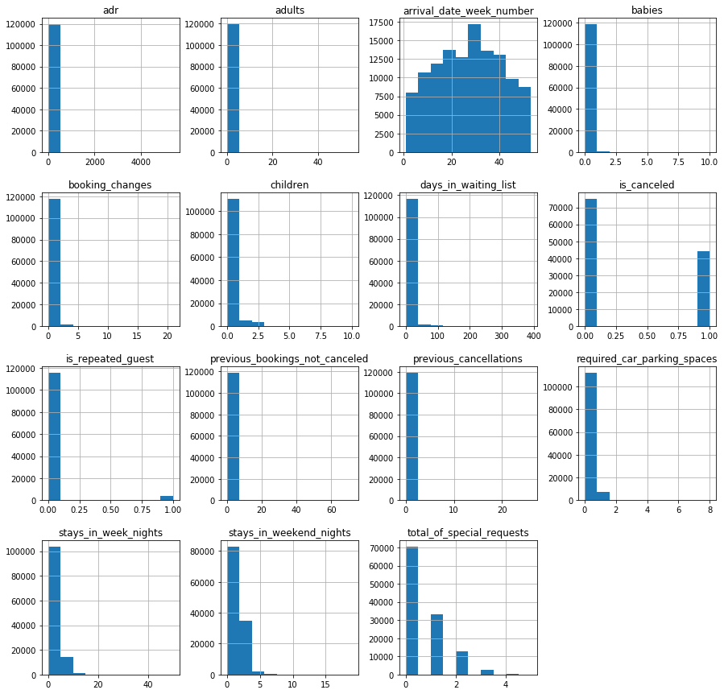

```python
df.hist(figsize=(15,15));
```